# Staff Turnover Analysis

Kevin Lin

### Part 1. 資料描述性統計：

首先，針對資料各欄位觀察其資料分布可初步了解資料概況

```
##       Age        Attrition            BusinessTravel   DailyRate
##  Min.   :18.00   No :1233   Non-Travel       : 150   Min.   : 102.0
##  1st Qu.:30.00   Yes: 237   Travel_Frequently: 277   1st Qu.: 465.0
##  Median :36.00              Travel_Rarely    :1043   Median : 802.0
##  Mean   :36.92                                       Mean   : 802.5
##  3rd Qu.:43.00                                       3rd Qu.:1157.0
##  Max.   :60.00                                       Max.   :1499.0
##
##                   Department  DistanceFromHome   Education
##  Human Resources       : 63   Min.   : 1.000   Min.   :1.000
##  Research & Development:961   1st Qu.: 2.000   1st Qu.:2.000
##  Sales                 :446   Median : 7.000   Median :3.000
##                               Mean   : 9.193   Mean   :2.913
##                               3rd Qu.:14.000   3rd Qu.:4.000
##                               Max.   :29.000   Max.   :5.000
##
##           EducationField EmployeeCount EmployeeNumber
##  Human Resources : 27    Min.   :1     Min.   :   1.0
##  Life Sciences   :606    1st Qu.:1     1st Qu.: 491.2
##  Marketing       :159    Median :1     Median :1020.5
##  Medical         :464    Mean   :1     Mean   :1024.9
##  Other           : 82    3rd Qu.:1     3rd Qu.:1555.8
##  Technical Degree:132    Max.   :1     Max.   :2068.0
##
##  EnvironmentSatisfaction    Gender      HourlyRate     JobInvolvement
##  Min.   :1.000           Female:588   Min.   : 30.00   Min.   :1.00
##  1st Qu.:2.000           Male  :882   1st Qu.: 48.00   1st Qu.:2.00
##  Median :3.000                        Median : 66.00   Median :3.00
##  Mean   :2.722                        Mean   : 65.89   Mean   :2.73
##  3rd Qu.:4.000                        3rd Qu.: 83.75   3rd Qu.:3.00
##  Max.   :4.000                        Max.   :100.00   Max.   :4.00
##
##     JobLevel                          JobRole    JobSatisfaction
##  Min.   :1.000   Sales Executive          :326   Min.   :1.000
##  1st Qu.:1.000   Research Scientist       :292   1st Qu.:2.000
##  Median :2.000   Laboratory Technician    :259   Median :3.000
##  Mean   :2.064   Manufacturing Director   :145   Mean   :2.729
##  3rd Qu.:3.000   Healthcare Representative:131   3rd Qu.:4.000
##  Max.   :5.000   Manager                  :102   Max.   :4.000
##                  (Other)                  :215
```

[output cut: 25 more lines]

```
##  Min.   :0.000         Min.   :1.000   Min.   : 0.000   Min.   : 0.000
##  1st Qu.:2.000         1st Qu.:2.000   1st Qu.: 3.000   1st Qu.: 2.000
##  Median :3.000         Median :3.000   Median : 5.000   Median : 3.000
##  Mean   :2.799         Mean   :2.761   Mean   : 7.008   Mean   : 4.229
##  3rd Qu.:3.000         3rd Qu.:3.000   3rd Qu.: 9.000   3rd Qu.: 7.000
##  Max.   :6.000         Max.   :4.000   Max.   :40.000   Max.   :18.000
##
##  YearsSinceLastPromotion YearsWithCurrManager
##  Min.   : 0.000          Min.   : 0.000
##  1st Qu.: 0.000          1st Qu.: 2.000
##  Median : 1.000          Median : 3.000
##  Mean   : 2.188          Mean   : 4.123
##  3rd Qu.: 3.000          3rd Qu.: 7.000
##  Max.   :15.000          Max.   :17.000
##
```

### Part 2. 探索式資料分析：

在對資料有初步了解後會針對一些變數購面來觀察其與離職的關係

#### 1. 基本訊息與離職與否的關係：

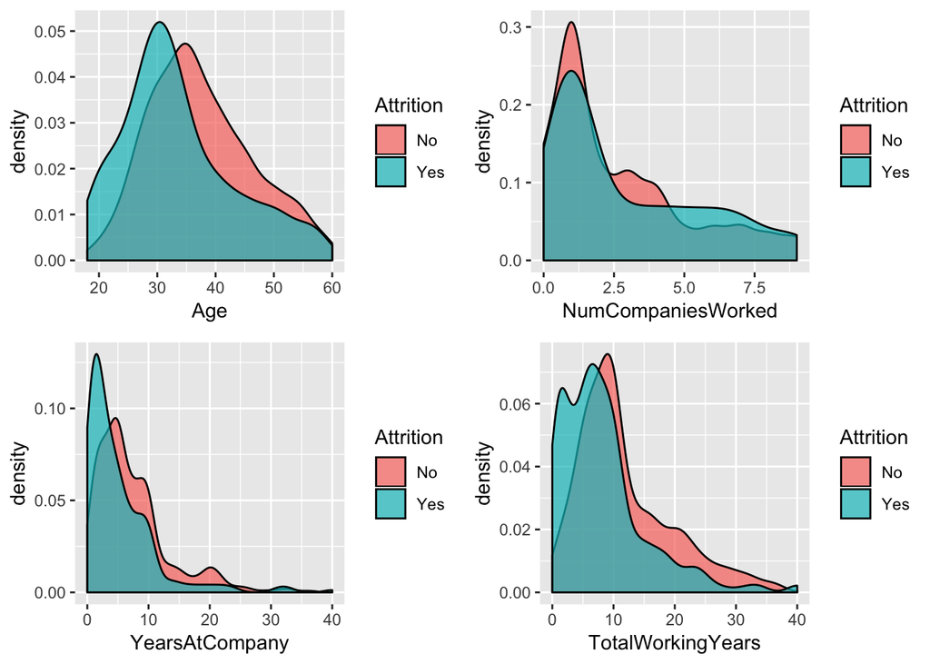

##### 結論：

- 年齡較低的流失率較高，主要集中在小於30歲的員工
- 在任職超過5家公司的員工???體中，該類員工的離職率高
- 在公司工作時間短的員工流失率高，年數小於4年的較為集中
- 工齡低的員工流失率高，集中在工齡小於7年左右的員工

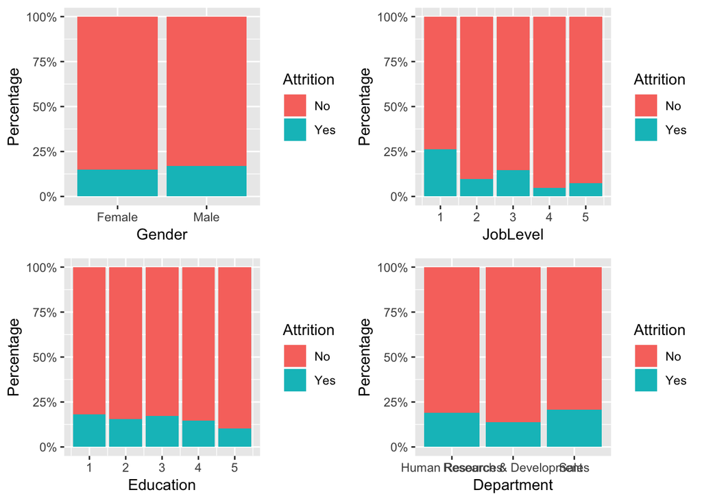

##### 結論：

- 低等級職位的員工的離職率高，主要集中在等級為1的職位
- 學歷和性別似乎沒有差異
- 銷售部門的員工較其他部門員工的流失率高

#### 2. 收入與離職與否的關係

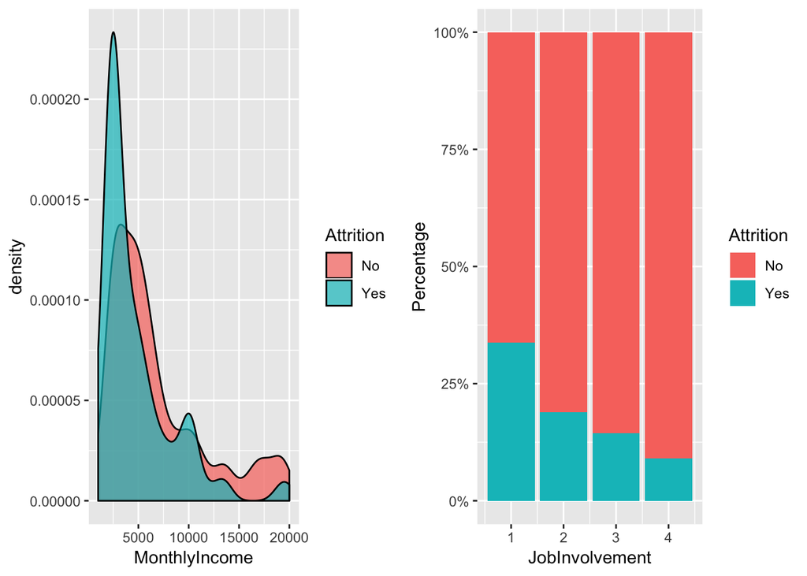

##### 結論：

- 收入低的員工離職率高，收入在10000美元左右的員工的離職率也不低
- 工作投入低的員工離職率高

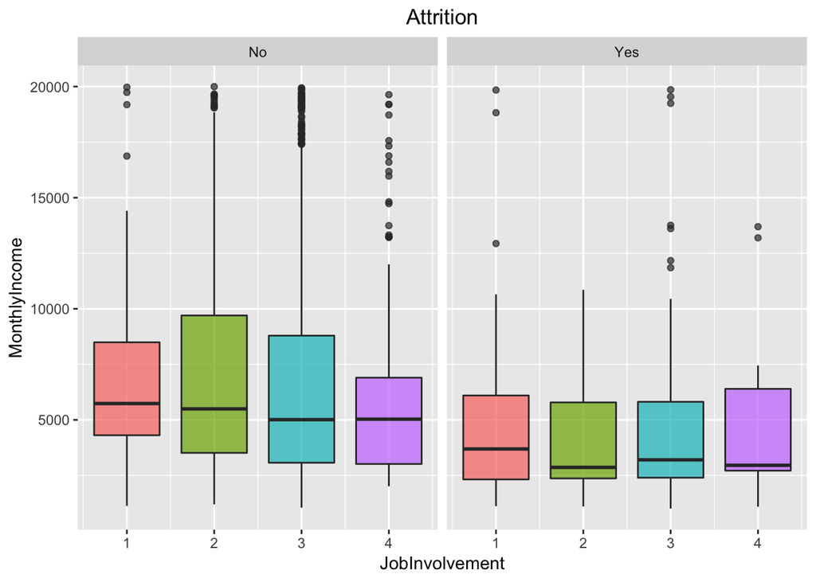

##### 結論：

- 在離職員工中,不同工作投入程度的員工所得薪資分布相似

#### 3. 福利、升遷與離職與否的關係

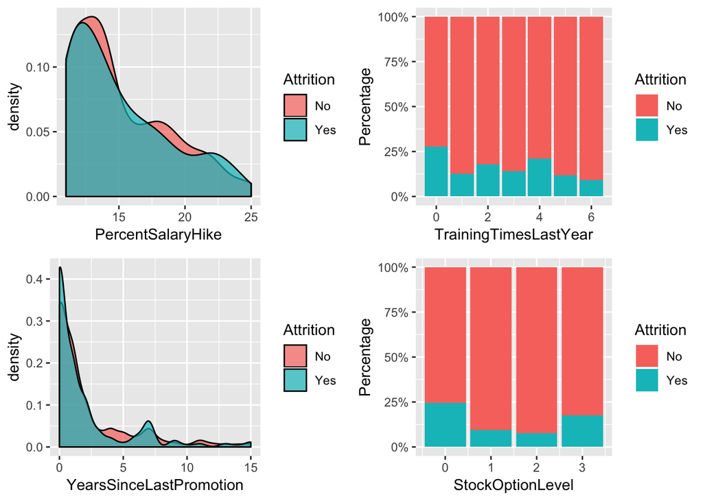

##### 結論：

- 沒有員工優先認股權的員工離職率較高
- 上一年沒有參與培訓的員工離職率高

#### 4. 滿意度相關變量與員工離職與否的關係

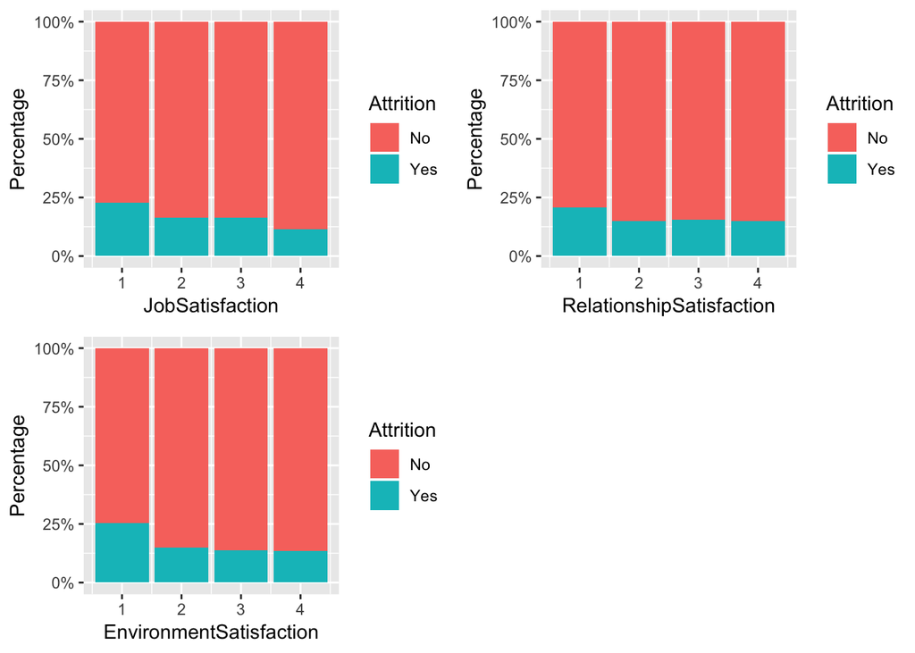

##### 結論：

- 無論何種滿意度，滿意度較低員工的離職率大於滿意度較高員工

#### 5. 工作生活平衡與員工離職與否的關係

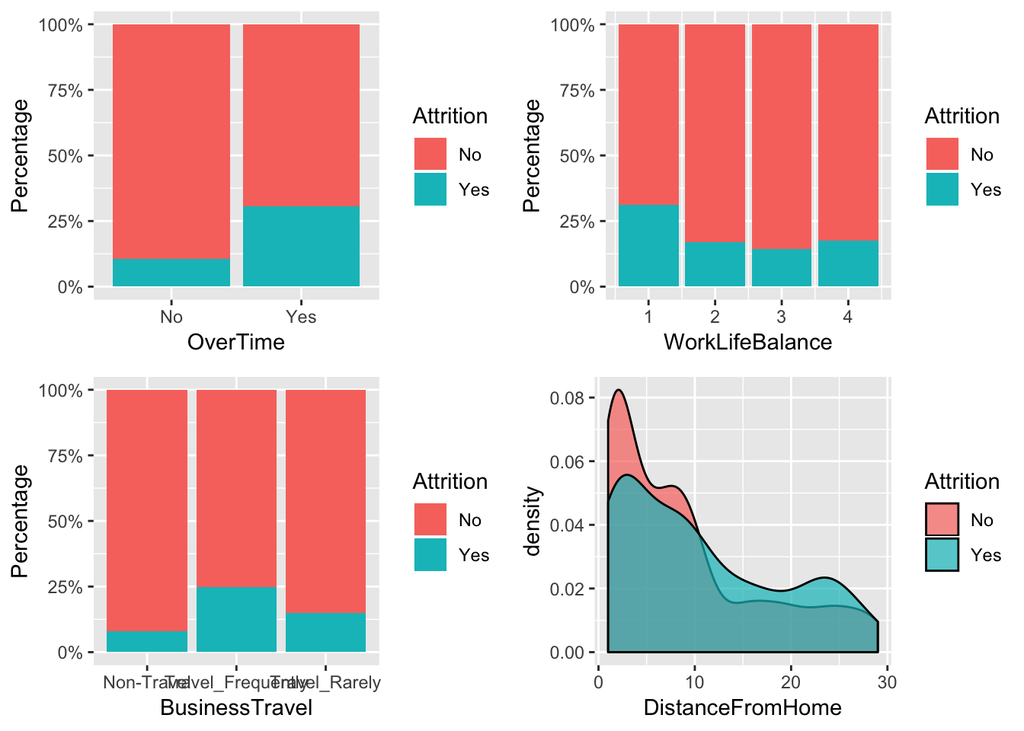

##### 結論：

- 經常加班的員工相對於不加班的員工離職率非常高
- 認為工作與生活平衡水平為1的員工離職率較高
- 頻繁出差的員工離職率較高高
- 距離家較遠的員工離職率較高

### Part 3. 模型建立：

在對資料做完探索式分析後， 會針對這些變數與離職的關係建立預測模型， 此次將用到分類中的兩個常用模型分別為Random Forest 及 GBM

#### Random Forest

```
## Area under the curve: 0.6287
```

```
##       Predicted
## Actual         No        Yes
##    No  0.92411924 0.07588076
##    Yes 0.66666667 0.33333333
```

##### 結論：

根據Random Forest跑出的結果可看出在初步嘗試下 模型效度僅達AUC約0.63，並無太突出的表現。

從混肴矩陣也可以觀察出模型於Recall上的表現僅有33%。

#### GBM

在使用GBM時，設定了樣本權重以解決樣本不均衡的問題

```
## Area under the curve: 0.7444
```

```
##       Predicted
## Actual        No       Yes
##    No  0.7804878 0.2195122
##    Yes 0.2916667 0.7083333
```

```
## gbm variable importance
##
##   only 20 most important variables shown (out of 44)
##
##                                  Overall
## MonthlyIncome                     100.00
## OverTimeYes                        95.59
## StockOptionLevel                   73.24
## Age                                54.07
## TotalWorkingYears                  37.88
## DailyRate                          37.60
## DistanceFromHome                   35.31
## MonthlyRate                        28.19
## RelationshipSatisfaction           28.15
## JobSatisfaction                    27.38
## YearsAtCompany                     25.31
## NumCompaniesWorked                 24.56
## YearsSinceLastPromotion            23.00
## WorkLifeBalance                    21.20
## MaritalStatusSingle                21.05
## EnvironmentSatisfaction            19.68
## JobRoleRsSci                       19.53
## YearsWithCurrManager               15.56
## DepartmentResearch & Development   13.65
## JobLevel                           13.45
```

##### 結論：

根據GBM跑出的結果可看出在樣本均衡校正下 模型效度由原本AUC約0.63提升至0.74。

同時從混肴矩陣也可以觀察出模型於Recall上的表現也進步許多。

另外，亦可由GBM的變數權重觀察出變數的重要程度順序： 前五重要性變數依序為：

月薪、是否超時工作、股票選擇權、年齡及年資。